# 1. Title:Preliminary-results

### b. Effect of treatments on time to pupate (ANOVA): Treatment 500 is the only one that shows significant differences #PLOT

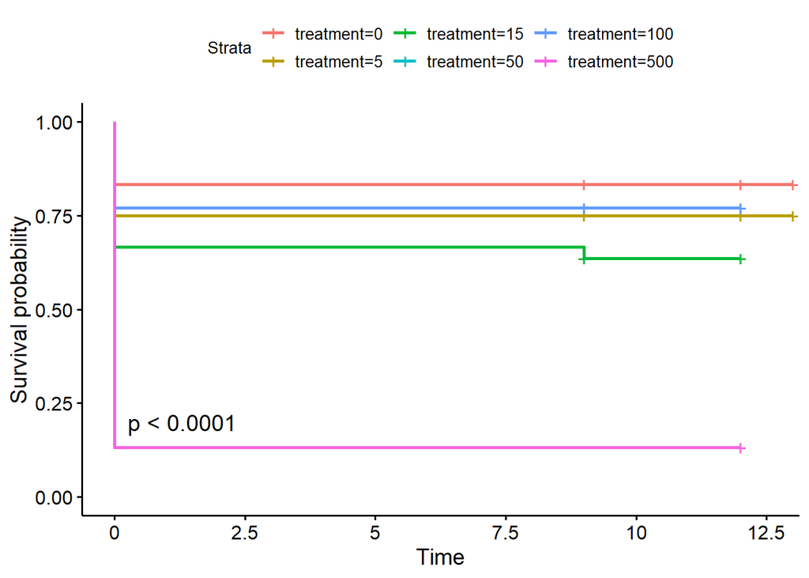

```r
#Part 2 - Analysis on time to pupate on the original defined survival, as for the redefined we weren't able to identify the individuals

#Now we do the same with time to pupate. We found it already hard to read, because of the numerous treatments so we decided to include the time to pupate in another ggplot.
surv_object <- Surv(time = survival$timetopup, event = survival$dead)
fit2 <- survfit(surv_object ~ treatment, data = survival)
#summary(fit2)
ggsurvplot(fit2, data = survival, main = "survival for pupate", pval = TRUE)
```

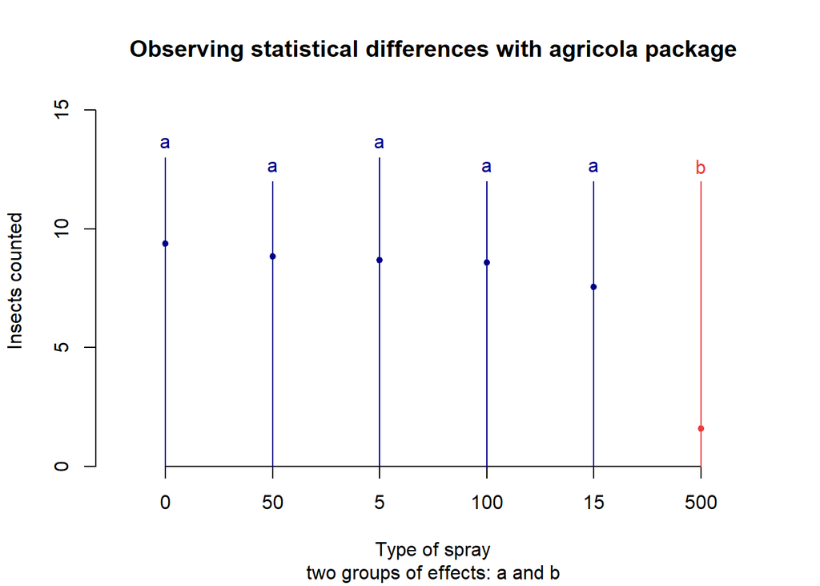

```r
#As many insects die while on treatment 500, the plot for time to pupate isn't very conclusive.

#ANOVA

survival <- surv
#plot(y=survival$timetopup, x= survival$treatment, xlab="Time to pupate" , ylab="Treatment")

#We know from previous analysis that treatment 500 is different. We proceed to study the differences between blocks and treatments for the time to pupate

lm1 <- lm(timetopup ~ treatment + exp_round, data= survival)
#summary(lm1)

#P value is bigger than 0.05 for: treatment500. The other treatments and the blocks show a p_value smaller than 0.5 so no significant effect.
#We proceed to study the interaction betwenn treatments and blocks.

lm1 <- lm(timetopup ~ treatment + exp_round +
            I(as.numeric(treatment) * as.numeric(exp_round)),
          data= survival)
#summary(lm1)

#No interaction, p = 0.27, do the anova

anv <- aov( lm(survival$timetopup ~ survival$treatment) )
#summary(anv)

#Anova shows significant differences between treatments. We proceed with a HSD test.

agri <- HSD.test(anv, 'survival$treatment', alpha = 0.05, group=TRUE, main = "HSD Test")
plot(agri, main = "Observing statistical differences with agricola package", ylab = "Insects counted", xlab = "Type of spray", sub = "two groups of effects: a and b")
```

```r
#Conclusions:
#Treatment 500 is the only one that shows significant differences in comparison with the control.
```

### c. Effects of treatments on behaviour

##### Step 1. Organizing the data.

We had to convert our data from the tibble format to a numeric dataframe.

```r
behaviour1 <- beha  ## making a copy of the originaml dataframe
behaviour1 <- as.data.frame(behaviour1)
row.names(behaviour1) <- paste(behaviour1$sample,
                               behaviour1$exp_round, sep = "_")
b1 <-select(behaviour1, S:M)
b2 <- data.frame(as.factor(beha$treatment), b1)
colnames(b2)[colnames(b2) == "as.factor.beha.treatment."] <- "treatment"
```

##### Step 2.Analysis

We ran the prcomp command to run a PCA on our dataframe.

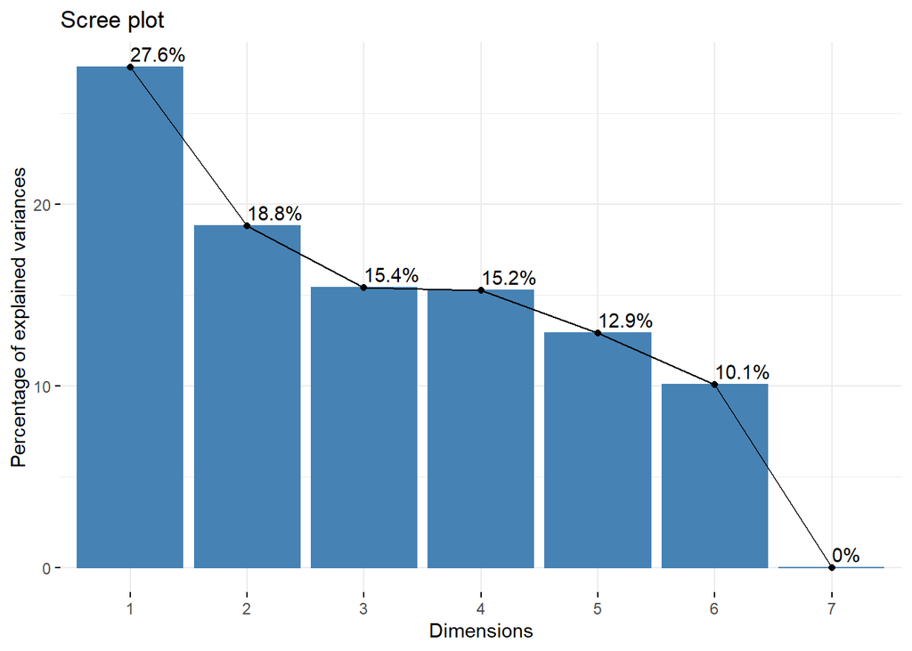

```r
pca1 <- prcomp(b1, scale = TRUE)

##Eigen values
eig.val <- get_eigenvalue(pca1)

##Scree plot
fviz_eig(pca1, addlabels = TRUE)
```

From the Eigen values and the Scree plot of our PCA we understand that Principal Component 1 and Principal Component 2 explain 46.4% of the variance in the data.

Heat mapping: The heat map explains shows which behaviour is best explained by which Principal Component.

```r
var <- get_pca_var(pca1)
var
```

```
## Principal Component Analysis Results for variables
##  ===================================================
##   Name       Description
## 1 "$coord"   "Coordinates for the variables"
## 2 "$cor"     "Correlations between variables and dimensions"
## 3 "$cos2"    "Cos2 for the variables"
## 4 "$contrib" "contributions of the variables"
```

```r
head(var$coord)
```

```
##          Dim.1      Dim.2      Dim.3       Dim.4       Dim.5       Dim.6
## S  -0.74557513  0.2798497 -0.4669022 -0.36112270 -0.13139440 -0.01127675
## GR -0.47976812  0.2497901  0.4523246  0.51349133  0.45802966 -0.17135984
## W   0.81088948  0.2595377 -0.1225145  0.09405303  0.19498914  0.46175709
## F   0.66251992  0.2702061  0.1919394 -0.25277152 -0.18018523 -0.59569650
## PR  0.08119856 -0.1549860 -0.3777860  0.76032670 -0.48113778 -0.13066524
## N  -0.02499383 -0.9379793  0.3007955 -0.14898929 -0.07076159  0.04341869
##           Dim.7
## S  -0.001724095
## GR -0.001086958
## W  -0.001522822
## F  -0.000895285
## PR -0.000480516
## N  -0.001450265
```

```r
head(var$cos2)
```

```
##           Dim.1      Dim.2      Dim.3       Dim.4       Dim.5        Dim.6
## S  0.5558822762 0.07831585 0.21799764 0.130409606 0.017264490 0.0001271651
## GR 0.2301774527 0.06239511 0.20459754 0.263673348 0.209791166 0.0293641947
## W  0.6575417464 0.06735980 0.01500979 0.008845973 0.038020764 0.2132196062
## F  0.4389326483 0.07301136 0.03684072 0.063893439 0.032466716 0.3548543179
## PR 0.0065932068 0.02402067 0.14272225 0.578096683 0.231493563 0.0170734053
## N  0.0006246913 0.87980508 0.09047793 0.022197807 0.005007203 0.0018851825
##           Dim.7
## S  2.972504e-06
## GR 1.181477e-06
## W  2.318987e-06
## F  8.015352e-07
## PR 2.308956e-07
## N  2.103268e-06
```

```r
head(var$contrib)
```

```
##          Dim.1     Dim.2     Dim.3      Dim.4      Dim.5       Dim.6     Dim.7
## S  28.81769827  5.948604 20.197127 12.2183692  1.9110275  0.01805297 30.889121
## GR 11.93271429  4.739319 18.955630 24.7041489 23.2220416  4.16868495 12.277461
## W  34.08786438  5.116420  1.390633  0.8287991  4.2085650 30.26969999 24.098019
## F  22.75486944  5.545693  3.413233  5.9863200  3.5937806 50.37685760  8.329247
## PR  0.34180087  1.824528 13.222984 54.1631781 25.6243066  2.42382426  2.399378
## N   0.03238485 66.826984  8.382633  2.0797625  0.5542534  0.26762974 21.856352
```

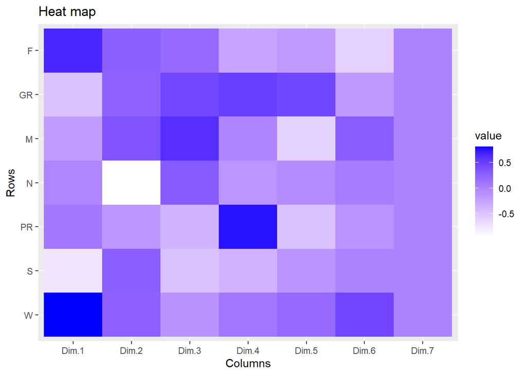

```r
autoplot(var$cor, main = "Heat map")
```

From the heat map we can visualize that the first two dimensions explain a largest degree of variance in our data. The third and fourth compnent also explain a large degree of the variance. The fourth dimension is a good fit for the probing behaviour (PR).

correlation circle:

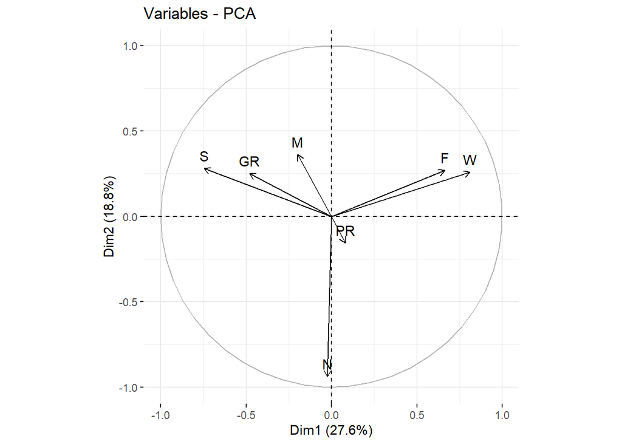

```r
fviz_pca_var(pca1, col.var = "black")
```

This plot of the correlation circle visualizes the correlation between the first two principal components which explain the highest variance which are respectively 27.6 % and 18.8%. We can conclude that Flying and walking are correlated together (the arrow are grouped), stationary and grooming are correlated together and the arrow which reprents feeding on nectar, pollen, and water is in the opposite direction and not correlated with others behaviours.

Individuals PCA

```
## Too few points to calculate an ellipse
```

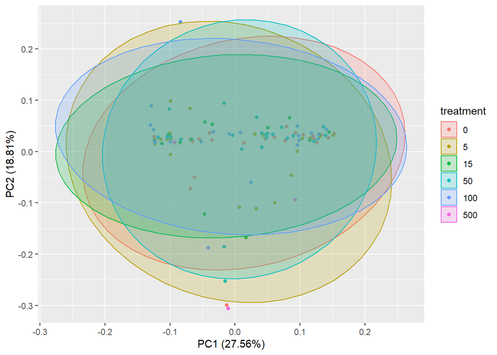

```r
autoplot(pca1, data = b2, colour = 'treatment', frame = TRUE, frame.type = 'norm')
```

This plot with ellipses shows the distribution of each behaviour following each treatment From this plot we can conclude that there is no significant difference between the effect of treatment on different behaviours because the ellipses overlap

Weight

```
## 'data.frame':    153 obs. of  6 variables:
##  $ Rep          : chr  "0/1_1" "0/2_1" "0/3_1" "0/4_1" ...
##  $ Treatment    : num  0 0 0 0 0 0 0 0 0 0 ...
##  $ FIL          : num  0 0 1 0 1 0 0 0 0 0 ...
##  $ Initialweight: num  0.031 0.029 0.026 0.023 0.023 0.024 0.029 0.025 0.022 0.04 ...
##  $ Finalweight  : num  0.389 0.35 0.315 0.35 0.361 0.364 0.393 0.373 0.336 0.342 ...
##  $ Difference   : num  0.358 0.321 0.289 0.327 0.338 0.34 0.364 0.348 0.314 0.302 ...
```

```
## 'data.frame':    153 obs. of  6 variables:
##  $ Rep          : chr  "0/1_1" "0/2_1" "0/3_1" "0/4_1" ...
##  $ Treatment    : Factor w/ 6 levels "0","5","15","50",..: 1 1 1 1 1 1 1 1 1 1 ...
##  $ FIL          : Factor w/ 2 levels "0","1": 1 1 2 1 2 1 1 1 1 1 ...
##  $ Initialweight: num  0.031 0.029 0.026 0.023 0.023 0.024 0.029 0.025 0.022 0.04 ...
##  $ Finalweight  : num  0.389 0.35 0.315 0.35 0.361 0.364 0.393 0.373 0.336 0.342 ...
##  $ Difference   : num  0.358 0.321 0.289 0.327 0.338 0.34 0.364 0.348 0.314 0.302 ...
```

```
##              Df  Sum Sq   Mean Sq F value Pr(>F)
## Treatment     5 0.00227 0.0004545     0.3  0.912
## Residuals   147 0.22280 0.0015156
```

```
##
##  Shapiro-Wilk normality test
##
## data:  res.aov$residuals
## W = 0.97855, p-value = 0.01725
```

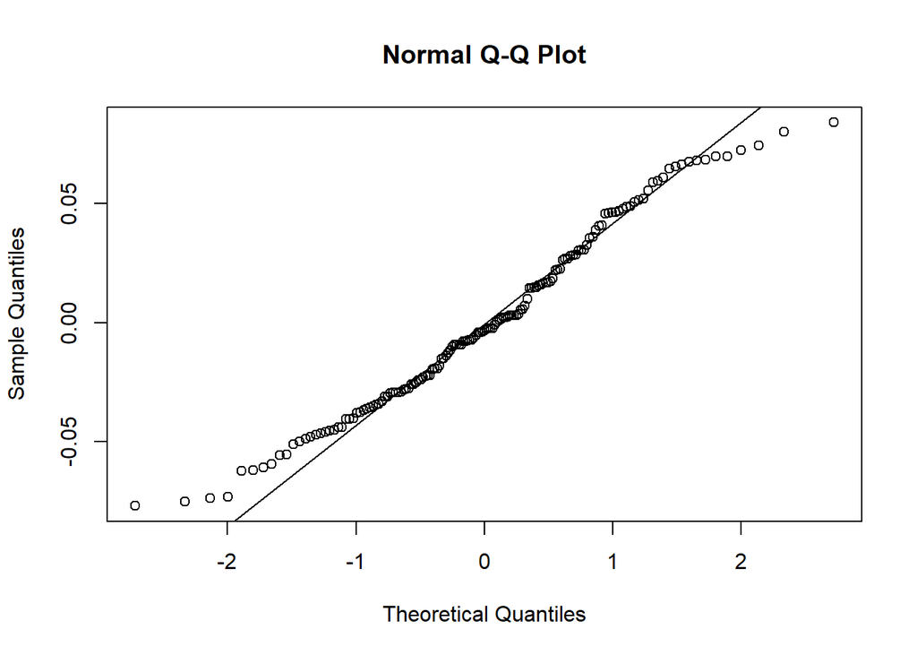

```
## Levene's Test for Homogeneity of Variance (center = median)
##        Df F value Pr(>F)
## group   5    0.42 0.8342
##       147
```

```
## $statistics
##      Chisq Df   p.chisq
##   1.363716  5 0.9282408
##
## $parameters
##             test p.ajusted                  name.t ntr alpha
##   Kruskal-Wallis      none Fordifference$Treatment   6  0.05
##
## $means
##     Fordifference.Difference     rank        std  r    Min   Max      Q25
## 0                  0.2990862 82.60345 0.03303602 29 0.2432 0.364 0.273100
## 100                0.2898037 70.57407 0.04213777 27 0.2164 0.374 0.263300
## 15                 0.2953536 75.94643 0.04004158 28 0.2213 0.364 0.264450
## 5                  0.2960828 77.50000 0.03692973 29 0.2336 0.366 0.266900
## 50                 0.2984964 80.17857 0.04253439 28 0.2231 0.373 0.266250
## 500                0.2874500 71.75000 0.03784179 12 0.2103 0.347 0.272975
##         Q50      Q75
## 0   0.29640 0.321000
## 100 0.28250 0.317000
## 15  0.28700 0.328500
## 5   0.29500 0.313000
## 50  0.29600 0.330250
## 500 0.28825 0.316425
##
## $comparison
## NULL
##
## $groups
##     Fordifference$Difference groups
## 0                   82.60345      a
## 50                  80.17857      a
## 5                   77.50000      a
## 15                  75.94643      a
## 500                 71.75000      a
## 100                 70.57407      a
##
## attr(,"class")
## [1] "group"
```

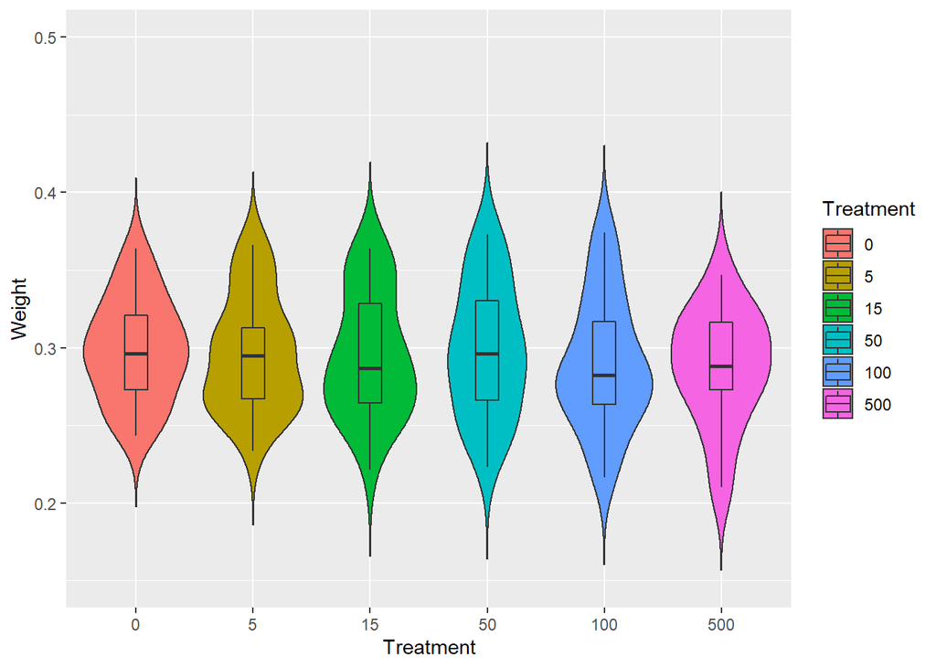

```
##
##      0  5 15 50 100 500
##   0 27 29 27 27  25  10
##   1  2  0  1  1   2   2
```

```
##
##  Fisher's Exact Test for Count Data
##
## data:  fil
## p-value = 0.3198
## alternative hypothesis: two.sided
```

## 7. Discussion. From your objectives.

Are to be done for the final presentation.

## 8. Conclusions.

We conclude that this project was hard but we learned a lot of stuff.